# W3cubDocs

/scikit-learn

# sklearn.linear_model.SGDClassifier

**`class sklearn.linear_model.SGDClassifier(loss=’hinge’, penalty=’l2’, alpha=0.0001, l1_ratio=0.15, fit_intercept=True, max_iter=None, tol=None, shuffle=True, verbose=0, epsilon=0.1, n_jobs=None, random_state=None, learning_rate=’optimal’, eta0=0.0, power_t=0.5, early_stopping=False, validation_fraction=0.1, n_iter_no_change=5, class_weight=None, warm_start=False, average=False, n_iter=None)` [[source]](https://github.com/scikit-learn/scikit-learn/blob/bac89c2/sklearn/linear_model/stochastic_gradient.py#L731)**

Linear classifiers (SVM, logistic regression, a.o.) with SGD training.

This estimator implements regularized linear models with stochastic gradient descent (SGD) learning: the gradient of the loss is estimated each sample at a time and the model is updated along the way with a decreasing strength schedule (aka learning rate). SGD allows minibatch (online/out-of-core) learning, see the partial_fit method. For best results using the default learning rate schedule, the data should have zero mean and unit variance.

This implementation works with data represented as dense or sparse arrays of floating point values for the features. The model it fits can be controlled with the loss parameter; by default, it fits a linear support vector machine (SVM).

The regularizer is a penalty added to the loss function that shrinks model parameters towards the zero vector using either the squared euclidean norm L2 or the absolute norm L1 or a combination of both (Elastic Net). If the parameter update crosses the 0.0 value because of the regularizer, the update is truncated to 0.0 to allow for learning sparse models and achieve online feature selection.

Read more in the User Guide.

[output not shown]

See also

`sklearn.svm.LinearSVC`, `LogisticRegression`, `Perceptron`

#### Examples

```
>>> import numpy as np
>>> from sklearn import linear_model
>>> X = np.array([[-1, -1], [-2, -1], [1, 1], [2, 1]])
>>> Y = np.array([1, 1, 2, 2])
>>> clf = linear_model.SGDClassifier(max_iter=1000)
>>> clf.fit(X, Y)
...
SGDClassifier(alpha=0.0001, average=False, class_weight=None,
       early_stopping=False, epsilon=0.1, eta0=0.0, fit_intercept=True,
       l1_ratio=0.15, learning_rate='optimal', loss='hinge', max_iter=1000,
       n_iter=None, n_iter_no_change=5, n_jobs=None, penalty='l2',
       power_t=0.5, random_state=None, shuffle=True, tol=None,
       validation_fraction=0.1, verbose=0, warm_start=False)
```

```
>>> print(clf.predict([[-0.8, -1]]))
[1]
```

#### Methods

| `decision_function`(X) | Predict confidence scores for samples. |
| --- | --- |
| `densify`() | Convert coefficient matrix to dense array format. |
| `fit`(X, y[, coef_init, intercept_init, …]) | Fit linear model with Stochastic Gradient Descent. |
| `get_params`([deep]) | Get parameters for this estimator. |
| `partial_fit`(X, y[, classes, sample_weight]) | Fit linear model with Stochastic Gradient Descent. |
| `predict`(X) | Predict class labels for samples in X. |
| `score`(X, y[, sample_weight]) | Returns the mean accuracy on the given test data and labels. |
| `set_params`(*args, **kwargs) |  |
| `sparsify`() | Convert coefficient matrix to sparse format. |

**`__init__(loss=’hinge’, penalty=’l2’, alpha=0.0001, l1_ratio=0.15, fit_intercept=True, max_iter=None, tol=None, shuffle=True, verbose=0, epsilon=0.1, n_jobs=None, random_state=None, learning_rate=’optimal’, eta0=0.0, power_t=0.5, early_stopping=False, validation_fraction=0.1, n_iter_no_change=5, class_weight=None, warm_start=False, average=False, n_iter=None)` [[source]](https://github.com/scikit-learn/scikit-learn/blob/bac89c2/sklearn/linear_model/stochastic_gradient.py#L959)**

**`decision_function(X)` [[source]](https://github.com/scikit-learn/scikit-learn/blob/bac89c2/sklearn/linear_model/base.py#L235)**

Predict confidence scores for samples.

The confidence score for a sample is the signed distance of that sample to the hyperplane.

[output not shown]

**`densify()` [[source]](https://github.com/scikit-learn/scikit-learn/blob/bac89c2/sklearn/linear_model/base.py#L314)**

Convert coefficient matrix to dense array format.

Converts the `coef_` member (back) to a numpy.ndarray. This is the default format of `coef_` and is required for fitting, so calling this method is only required on models that have previously been sparsified; otherwise, it is a no-op.

| Returns: | **`self : estimator`** |
| --- | --- |

**`fit(X, y, coef_init=None, intercept_init=None, sample_weight=None)` [[source]](https://github.com/scikit-learn/scikit-learn/blob/bac89c2/sklearn/linear_model/stochastic_gradient.py#L697)**

Fit linear model with Stochastic Gradient Descent.

[output not shown]

**`get_params(deep=True)` [[source]](https://github.com/scikit-learn/scikit-learn/blob/bac89c2/sklearn/base.py#L166)**

Get parameters for this estimator.

| Parameters: | **`deep : boolean, optional`** If True, will return the parameters for this estimator and contained subobjects that are estimators. |
| --- | --- |
| Returns: | **`params : mapping of string to any`** Parameter names mapped to their values. |

**`loss_function`**

DEPRECATED: Attribute loss_function was deprecated in version 0.19 and will be removed in 0.21. Use `loss_function_` instead

**`partial_fit(X, y, classes=None, sample_weight=None)` [[source]](https://github.com/scikit-learn/scikit-learn/blob/bac89c2/sklearn/linear_model/stochastic_gradient.py#L655)**

Fit linear model with Stochastic Gradient Descent.

[output not shown]

**`predict(X)` [[source]](https://github.com/scikit-learn/scikit-learn/blob/bac89c2/sklearn/linear_model/base.py#L268)**

Predict class labels for samples in X.

| Parameters: | **`X : array_like or sparse matrix, shape (n_samples, n_features)`** Samples. |
| --- | --- |
| Returns: | **`C : array, shape [n_samples]`** Predicted class label per sample. |

**`predict_log_proba`**

Log of probability estimates.

This method is only available for log loss and modified Huber loss.

When loss=”modified_huber”, probability estimates may be hard zeros and ones, so taking the logarithm is not possible.

See `predict_proba` for details.

| Parameters: | **`X : array-like, shape (n_samples, n_features)`** |
| --- | --- |
| Returns: | **`T : array-like, shape (n_samples, n_classes)`** Returns the log-probability of the sample for each class in the model, where classes are ordered as they are in `self.classes_`. |

**`predict_proba`**

Probability estimates.

This method is only available for log loss and modified Huber loss.

Multiclass probability estimates are derived from binary (one-vs.-rest) estimates by simple normalization, as recommended by Zadrozny and Elkan.

Binary probability estimates for loss=”modified_huber” are given by (clip(decision_function(X), -1, 1) + 1) / 2. For other loss functions it is necessary to perform proper probability calibration by wrapping the classifier with `sklearn.calibration.CalibratedClassifierCV` instead.

| Parameters: | **`X : {array-like, sparse matrix}, shape (n_samples, n_features)`** |
| --- | --- |
| Returns: | **array, shape (n_samples, n_classes)** Returns the probability of the sample for each class in the model, where classes are ordered as they are in `self.classes_`. |

#### References

Zadrozny and Elkan, “Transforming classifier scores into multiclass probability estimates”, SIGKDD‘02, http://www.research.ibm.com/people/z/zadrozny/kdd2002-Transf.pdf

The justification for the formula in the loss=”modified_huber” case is in the appendix B in: http://jmlr.csail.mit.edu/papers/volume2/zhang02c/zhang02c.pdf

**`score(X, y, sample_weight=None)` [[source]](https://github.com/scikit-learn/scikit-learn/blob/bac89c2/sklearn/base.py#L263)**

Returns the mean accuracy on the given test data and labels.

In multi-label classification, this is the subset accuracy which is a harsh metric since you require for each sample that each label set be correctly predicted.

[output not shown]

**`sparsify()` [[source]](https://github.com/scikit-learn/scikit-learn/blob/bac89c2/sklearn/linear_model/base.py#L332)**

Convert coefficient matrix to sparse format.

Converts the `coef_` member to a scipy.sparse matrix, which for L1-regularized models can be much more memory- and storage-efficient than the usual numpy.ndarray representation.

The `intercept_` member is not converted.

| Returns: | **`self : estimator`** |
| --- | --- |

#### Notes

For non-sparse models, i.e. when there are not many zeros in `coef_`, this may actually *increase* memory usage, so use this method with care. A rule of thumb is that the number of zero elements, which can be computed with `(coef_ == 0).sum()`, must be more than 50% for this to provide significant benefits.

After calling this method, further fitting with the partial_fit method (if any) will not work until you call densify.

## Examples using `sklearn.linear_model.SGDClassifier`

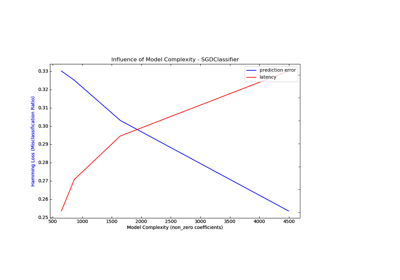

Model Complexity Influence

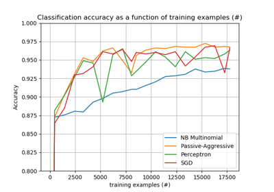

Out-of-core classification of text documents

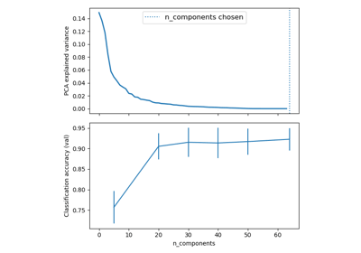

Pipelining: chaining a PCA and a logistic regression

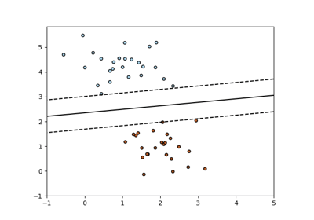

SGD: Maximum margin separating hyperplane

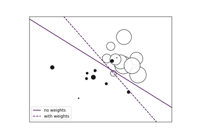

SGD: Weighted samples

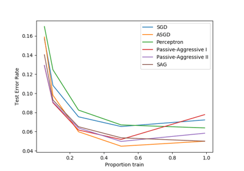

Comparing various online solvers

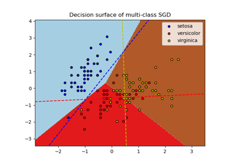

Plot multi-class SGD on the iris dataset

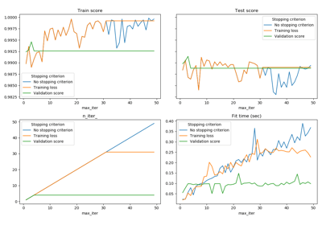

Early stopping of Stochastic Gradient Descent

[figure not shown]

Sample pipeline for text feature extraction and evaluation

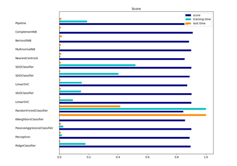

Classification of text documents using sparse features

© 2007–2018 The scikit-learn developers  
Licensed under the 3-clause BSD License.  
http://scikit-learn.org/stable/modules/generated/sklearn.linear_model.SGDClassifier.html